# BiocParallel and knitrBootstrap intro

April 2nd, 2015

- Presentation: lcolladotor.github.io/BiocParallel-knitrBootstrap/
- R code: lcolladotor.github.io/BiocParallel-knitrBootstrap/index.R

## Installation

This is a short introduction on how to use `BiocParallel` (Morgan, Lang, and Thompson, 2015) and `knitrBootstrap` ([Hester, 2014](https://github.com/jimhester/)).

You will need R 3.1.2 or newer (available from [CRAN](http://cran.r-project.org/)) and [BiocParallel](http://bioconductor.org/packages/release/bioc/html/BiocParallel.html)

```r
## Install BiocParallel
source('http://bioconductor.org/biocLite.R')
biocLite('BiocParallel')
```

You will also need knitrBootstrap

```r
## If needed:
# install.packages('devtools')
devtools::install_github('jimhester/knitrBootstrap')
```

## Docs

You can find the latest documentation at

- [Introduction to BiocParallel](http://bioconductor.org/packages/devel/bioc/vignettes/BiocParallel/inst/doc/IntroductionToBiocParallel.pdf) vignette
- [knitrBootstrap README](https://github.com/jimhester/knitrBootstrap/blob/master/README.md)
- help pages

```r
help(package = 'BiocParallel')
help(package = 'knitrBootstrap')
```

## Parallel computing?

## Hm…

[figure not shown]

[Source](http://gnoted.com/wp-content/uploads/2012/02/cloud_43-595x553.jpg)

[figure not shown]

[Source](http://www.mathworks.com/cmsimages/63635_wl_91710v00_po_fig2_wl.gif)

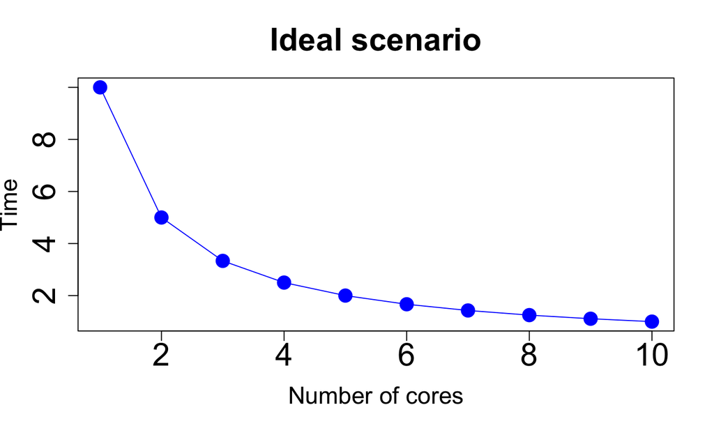

```r
plot(y = 10 / (1:10), 1:10, xlab = 'Number of cores', ylab = 'Time',
    main = 'Ideal scenario', type = 'o', col = 'blue',
    cex = 2, cex.axis = 2, cex.lab = 1.5, cex.main = 2, pch = 16)
```

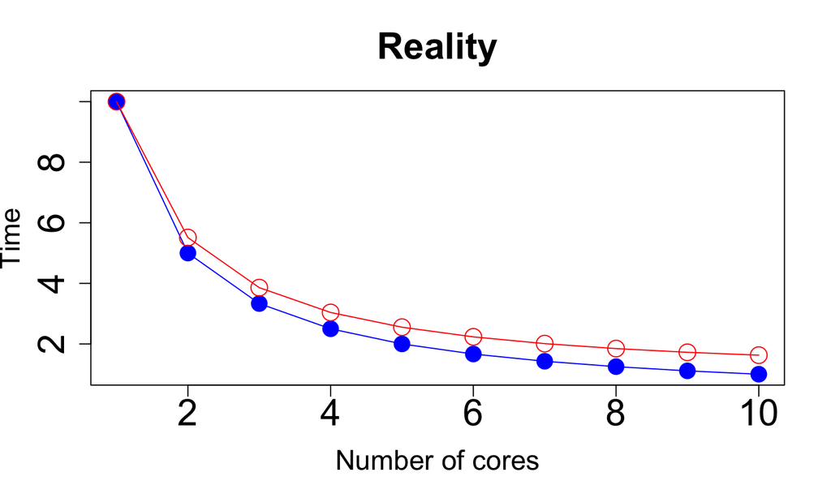

```r
plot(y = 10 / (1:10), 1:10, xlab = 'Number of cores', ylab = 'Time',
    main = 'Reality', type = 'o', col = 'blue',
    cex = 2, cex.axis = 2, cex.lab = 1.5, cex.main = 2, pch = 16)
lines(y = 10 / (1:10) * c(1, 1.05^(2:10) ), 1:10, col = 'red',
    type = 'o', cex = 2)
```

[CRAN Task View: High-Performance and Parallel Computing with R](http://cran.r-project.org/web/views/HighPerformanceComputing.html)

[figure not shown]

[Source](http://thumbs.dreamstime.com/x/word-cloud-parallel-computing-27198811.jpg)

## BiocParallel authors

[figure not shown]

- Martin Morgan
- Ryan Thompson
- Michel Lang
- [Valerie Obenchain](https://github.com/vobencha) (couldn't find pic)

## Birthday example

```r
birthday <- function(n) {
    m <- 10000
    x <- numeric(m)
    for(i in 1:m) {
        b <- sample(1:365, n, replace = TRUE)
        x[i] <- ifelse(length(unique(b)) == n, 0, 1)
    }
    mean(x)
}
```

```r
system.time( lapply(1:100, birthday) )
```

```
##    user  system elapsed
##  24.119   0.251  24.388
```

[Source](http://www.slideshare.net/RevolutionAnalytics/introducing-revolution-r-open-enhanced-open-source-r-distribution-from-revolution-analytics) slide 24

## Via doMC

```r
library('doMC')
registerDoMC(2)
system.time( x <- foreach(j = 1:100) %dopar% birthday(j) )
```

```
##    user  system elapsed
##  19.263   0.315  22.145
```

- Have to change code
- Want to try another parallel mode? Change code again

## Via BiocParallel

```r
library('BiocParallel')
system.time( y <- bplapply(1:100, birthday) )
```

```
##    user  system elapsed
##   0.238   0.075  12.789
```

- Very easy: change lapply() to `bp`lapply()
- Can set global options

## Registered modes

```r
registered()
```

```
## $MulticoreParam
## class: MulticoreParam
## bpworkers: 4
## bpisup: FALSE
## bplog: FALSE
## bpthreshold:
## bplogdir:
## bpresultdir:
## bpstopOnError: FALSE
## cluster type:  FORK
##
## $SnowParam
## class: SnowParam
## bpworkers: 4
## bpisup: FALSE
## bplog: FALSE
## bpthreshold: INFO
## bplogdir:
## bpresultdir:
## bpstopOnError: FALSE
## cluster type:  SOCK
##
## $SerialParam
## class: SerialParam
## bpworkers: 1
```

## Change modes

```r
## Test in serial mode
system.time( y.serial <- bplapply(1:10, birthday,
    BPPARAM = SerialParam()) )
```

```
##    user  system elapsed
##   2.103   0.017   2.124
```

```r
## Try Snow
system.time( y.snow <- bplapply(1:10, birthday,
    BPPARAM = SnowParam(workers = 2)) )
```

```
##    user  system elapsed
##   0.026   0.019   1.738
```

## Use in JHPCE

```
$ R
> library('BiocParallel')
> registered()
$MulticoreParam
class: MulticoreParam; bpisup: TRUE; bpworkers: 8; catch.errors: TRUE
setSeed: TRUE; recursive: TRUE; cleanup: TRUE; cleanupSignal: 15;
  verbose: FALSE

$SnowParam
class: SnowParam; bpisup: FALSE; bpworkers: 8; catch.errors: TRUE
cluster spec: 8; type: PSOCK

$BatchJobsParam
class: BatchJobsParam; bpisup: TRUE; bpworkers: NA; catch.errors: TRUE
cleanup: TRUE; stop.on.error: FALSE; progressbar: TRUE

$SerialParam
class: SerialParam; bpisup: TRUE; bpworkers: 1; catch.errors: TRUE
```

## BatchJobs

- Submits jobs for you in many cluster environments
- Lots of docs: [rdocumentation.org/packages/BatchJobs](http://www.rdocumentation.org/packages/BatchJobs/functions/BatchJobs)
- Also https://github.com/tudo-r/BatchJobs/wiki/Configuration

## .BatchJobs.R file

```r
cluster.functions = makeClusterFunctionsSGE("~/simple.tmpl")
mail.start = "none"
mail.done = "none"
mail.error = "none"
staged.queries = TRUE
fs.timeout = 10
```

Via [Prasad Patil](http://www.biostat.jhsph.edu/~prpatil/)

## simple.tmpl file

```bash
#!/bin/bash
# Job name
#$ -N <%= job.name %>
# Use current directory
#$ -cwd
# Get emails
#$ -m e

R CMD BATCH --no-save --no-restore "<%= rscript %>" /dev/stdout
exit 0
```

Modified from [Prasad's](http://www.biostat.jhsph.edu/~prpatil/) version.

I like emails to then explore stats using Alyssa's [efficency SGE analytics](http://alyssafrazee.com/efficiency-analytics.html): [code](http://figshare.com/articles/efficiency_analytics/878000).

## General simple.tmpl file

```bash
#!/bin/bash

# The name of the job, can be anything, simply used when displaying the list of running jobs
#$ -N <%= job.name %>
# Combining output/error messages into one file
#$ -j y
# Giving the name of the output log file
#$ -o <%= log.file %>
# One needs to tell the queue system to use the current directory as the working directory
# Or else the script may fail as it will execute in your top level home directory /home/username
#$ -cwd
# use environment variables
#$ -V
# use correct queue
#$ -q <%= resources$queue %>
# use job arrays
#$ -t 1-<%= arrayjobs %>

# we merge R output with stdout from SGE, which gets then logged via -o option
R CMD BATCH --no-save --no-restore "<%= rscript %>" /dev/stdout
exit 0
```

[Source](https://github.com/tudo-r/BatchJobs/blob/master/examples/cfSGE/simple.tmpl)

## Actually using it

```r
library('BiocParallel')
library('BatchJobs')

# define birthday() function

## Register cluster
funs <- makeClusterFunctionsSGE("~/simple.tmpl")
param <- BatchJobsParam(workers = 10, resources = list(ncpus = 1),
    cluster.functions = funs)
register(param)

## Run
system.time( xx <- bplapply(1:100, birthday) )

## Jobs spend a little bit of time in the queue
#   user  system elapsed
#  0.597   0.350  31.644
```

## Important note

For developers:

```
Developers wishing to invoke back-ends other than MulticoreParam
need to take special care to ensure that required packages, data,
and functions are available and loaded on the remote nodes.
```

Source: [BiocParallel vignette](http://bioconductor.org/packages/devel/bioc/vignettes/BiocParallel/inst/doc/IntroductionToBiocParallel.pdf)

## Why should I use `BiocParallel`?

- Simple to use
- Try different parallel backends without changing code
- Can use it to submit cluster jobs
- Great support from Bioconductor team

## HTML reports

People like them because

- easy to share
- we all use the web
- can have interactive features

[figure not shown]

[Source](https://rawgit.com/yihui/knitr-examples/master/003-minimal.html)

- `rmarkdown` ([Allaire, McPherson, Xie, Wickham, et al., 2014](http://CRAN.R-project.org/package=rmarkdown)) has simplified the process
- http://rmarkdown.rstudio.com/

[figure not shown]

[Source](http://rmarkdown.rstudio.com/)

## knitrBootstrap

[Creating awesome reports for multiple audiences using knitrBootstrap](http://lcolladotor.github.io/2013/12/10/knitrBootstrap/#.VRzPvTvF90s)

- Idea:
- One document with code and output
- Hide code by default
- Users who like code, can easily look at it
- Users who don't need code don't get confused by it

## Example myFile.Rmd

```
---
output:
  knitrBootstrap::bootstrap_document:
    theme.chooser: TRUE
    highlight.chooser: TRUE
---

Title
====

Etc
```

Then render:

```r
rmarkdown::render('myFile.Rmd')
```

## Useful chunk options

```
bootstrap.show.code = FALSE
bootstrap.show.warning = FALSE
bootstrap.show.message = FALSE
```

[figure not shown]

## Need help?

- Post in the [Bioconductor support site](https://support.bioconductor.org/) – remember to use the `BiocParallel` tag!
- For `knitrBootstrap`, open a new [issue in the GitHub repo](https://github.com/jimhester/knitrBootstrap/issues)

## Citing them

```r
## Citation info
citation('BiocParallel')
```

```
##
##
##   Martin Morgan, Michel Lang and Ryan Thompson (). BiocParallel:
##   Bioconductor facilities for parallel evaluation. R package
##   version 1.1.21.
##
## A BibTeX entry for LaTeX users is
##
##   @Manual{,
##     title = {BiocParallel: Bioconductor facilities for parallel evaluation},
##     author = {Martin Morgan and Michel Lang and Ryan Thompson},
##     note = {R package version 1.1.21},
##   }
```

```r
citation('knitrBootstrap')
```

```
##
##
##   Jim Hester (2014). knitrBootstrap: Knitr Bootstrap framework.. R
##   package version 1.0.0. https://github.com/jimhester/
##
## A BibTeX entry for LaTeX users is
##
##   @Manual{,
##     title = {knitrBootstrap: Knitr Bootstrap framework.},
##     author = {Jim Hester},
##     year = {2014},
##     note = {R package version 1.0.0},
##     url = {https://github.com/jimhester/},
##   }
##
## ATTENTION: This citation information has been auto-generated from
## the package DESCRIPTION file and may need manual editing, see
## 'help("citation")'.
```

## Reproducibility

Code for creating this page

```r
## Create this page
library('rmarkdown')
render('index.Rmd')

## Clean up
file.remove('BiocParallel-knitrBootstrap.bib')

## Extract the R code
library('knitr')
knit('index.Rmd', tangle = TRUE)
```

Date this tutorial was generated.

```
## [1] "2015-04-02 01:31:11 EDT"
```

Wallclock time spent running this tutorial.

```
## Time difference of 1.095 mins
```

`R` session information.

```
##  setting  value
##  version  R Under development (unstable) (2014-11-01 r66923)
##  system   x86_64, darwin10.8.0
##  ui       AQUA
##  language (EN)
##  collate  en_US.UTF-8
##  tz       America/New_York
```

```
##  package        * version  date       source
##  bibtex           0.4.0    2014-12-31 CRAN (R 3.2.0)
##  BiocParallel   * 1.1.21   2015-03-24 Bioconductor
##  bitops           1.0.6    2013-08-17 CRAN (R 3.2.0)
##  codetools        0.2.11   2015-03-10 CRAN (R 3.2.0)
##  devtools       * 1.6.1    2014-10-07 CRAN (R 3.2.0)
##  digest           0.6.8    2014-12-31 CRAN (R 3.2.0)
##  doMC           * 1.3.3    2014-02-28 CRAN (R 3.2.0)
##  evaluate         0.5.5    2014-04-29 CRAN (R 3.2.0)
##  foreach        * 1.4.2    2014-04-11 CRAN (R 3.2.0)
##  formatR          1.0      2014-08-25 CRAN (R 3.2.0)
##  futile.logger    1.4      2015-03-21 CRAN (R 3.2.0)
##  futile.options   1.0.0    2010-04-06 CRAN (R 3.2.0)
##  htmltools        0.2.6    2014-09-08 CRAN (R 3.2.0)
##  httr             0.5      2014-09-02 CRAN (R 3.2.0)
##  iterators      * 1.0.7    2014-04-11 CRAN (R 3.2.0)
##  knitcitations  * 1.0.4    2014-11-03 Github (cboettig/knitcitations@508de74)
##  knitr            1.7      2014-10-13 CRAN (R 3.2.0)
##  lambda.r         1.1.7    2015-03-20 CRAN (R 3.2.0)
##  lubridate        1.3.3    2013-12-31 CRAN (R 3.2.0)
##  memoise          0.2.1    2014-04-22 CRAN (R 3.2.0)
##  plyr             1.8.1    2014-02-26 CRAN (R 3.2.0)
##  Rcpp             0.11.5   2015-03-06 CRAN (R 3.2.0)
##  RCurl            1.95.4.5 2014-12-28 CRAN (R 3.2.0)
##  RefManageR       0.8.40   2014-10-29 CRAN (R 3.2.0)
##  RJSONIO          1.3.0    2014-07-28 CRAN (R 3.2.0)
##  rmarkdown      * 0.3.3    2014-09-17 CRAN (R 3.2.0)
##  rstudioapi       0.2      2014-12-31 CRAN (R 3.2.0)
##  snow             0.3.13   2013-09-27 CRAN (R 3.2.0)
##  stringr          0.6.2    2012-12-06 CRAN (R 3.2.0)
##  XML              3.98.1.1 2013-06-20 CRAN (R 3.2.0)
##  yaml             2.1.13   2014-06-12 CRAN (R 3.2.0)
```

## Bibliography

This tutorial was generated using `rmarkdown` ([Allaire, McPherson, Xie, Wickham, et al., 2014](http://CRAN.R-project.org/package=rmarkdown)) and `knitcitations` ([Boettiger, 2015](https://github.com/cboettig/knitcitations)).

[1] J. Allaire, J. McPherson, Y. Xie, H. Wickham, et al. *rmarkdown: Dynamic Documents for R*. R package version 0.3.3. 2014. URL: http://CRAN.R-project.org/package=rmarkdown.

[2] C. Boettiger. *knitcitations: Citations for knitr markdown files*. R package version 1.0.4. 2015. URL: https://github.com/cboettig/knitcitations.

[3] J. Hester. *knitrBootstrap: Knitr Bootstrap framework.* R package version 1.0.0. 2014. URL: https://github.com/jimhester/.

[4] M. Morgan, M. Lang and R. Thompson. *BiocParallel: Bioconductor facilities for parallel evaluation*. R package version 1.1.21. 2015.